# Problem Set 2

## Part I. Exercises for Chapter 4: Graphical Analysis

## Problem 1:

$$F(x) = x^2 - 1.1$$

## (a)

$$ \begin{align*} F(x) &= x \qquad & \text{This must be true for x to be fixed} \\ x^2 - 1.1 &= x \\ x^2 - x &= 1.1 \\ x^2 - x + 0.25 &= 1.35 \qquad & \text{Left side of equation made perfect square} \\ (x - 0.5)^2 &= 1.35 \\ x - 0.5 &= \pm\sqrt{1.35} \\ x &= 0.5 \pm\sqrt{1.35} \end{align*} $$

## (b)

$$ \begin{align*} F^2(x) &= x \qquad & \text{This must me true for x to be a 2-cycle} \\ (x^2 - 1.1)^2 - 1.1 &= x \qquad & \text{By substituting $F(x)$ into $x$} \\ x^4 - 2.2x^2 + 1.21 - 1.1 &= x \\ x^4 - 2.2x^2 - x + 0.11 &= 0 \\ (x^2 - x - 1.1)(x^2 + x - 0.1) &= 0 \qquad & \text{Factoring possible because fixed points are also 2-cycles} \\ x = 0.5(-1 \pm \sqrt{1-4(-0.1)})& \qquad & \text{Quadratic equation on second factor} \\ x = -0.5 \pm \sqrt{0.35}& \end{align*} $$$$F(x) \text{ has fixed points at } x_0 = 0.5 \pm \sqrt{1.35} \text{ and 2-cycles at } x_0 = -0.5 \pm \sqrt{0.35}\text{.}$$

## Problem 2:

## (a)

$$F(x) = \frac{1}{x}$$

$\textbf{Finding fixed points:}$ $$ \begin{align*} F(x) &= x \\ \frac{1}{x} &= x \\ x^2 &= 1 \\ x &= \pm 1 \end{align*} $$

$\textbf{Finding 2-cycles:}$ $$ \begin{align*} F^2(x) &= x \\ \frac{1}{\frac{1}{x}} &= x \\ x &= x \\ x &\in \mathbb{R} \end{align*} $$

$$F(x) = \frac{1}{x} \text{ has fixed points at } x_0 = \pm 1 \text{ and all other seed values lie on periodic 2-cycles.}$$

## (b)

$$F(x) = e^x$$

$F(x) = e^x > x$ for all $x \in \mathbb{R}$. To demonstrate this, let's express the difference between $e^x$ and $x$ at a given x-value as $d(x) = e^x - x$. If $e^x = x$ at some x-value $c$, then $d(c)$ will equal 0. Let's find $d(x)$'s critical points. $d'(x) = e^x - 1$, which is only ever equal to 0 at $x = 0$. $d''(0) = e^0 = 1$, so $x = 0$ is a relative minimum of $d(x)$ and, as the only critical point of the function, must be the absolute minimum of $d(x)$. $d(0) = 1 > 0$, meaning that $d(x)$ is always greater than 0, so $e^x > x$ for all $x \in \mathbb{R}$. Thus, all orbits on $F(x)$ diverge to $\infty$.

## (c)

$$F(x) = x^2 + 1$$

$F(x) = x^2 + 1 > x$ for all $x \in \mathbb{R}$. Like in (b), we can consider the difference $d(x) = x^2 - x + 1$. Because the discriminant for this function is negative and the leading coefficient is positive, we know that $d(x) > 0$ and consequently that $x^2 + 1 > x$ for all $x \in \mathbb{R}$. Therefore, all orbits on $F(x)$ diverge to $\infty$.

## Problem 4:

$$F(x) = x\sin x$$

## Setting Up Tools:

```python
from math import *
import numpy as np
import matplotlib.pyplot as plt
```

Functions to generate cobweb diagrams:

```python
# Driver function to make cobweb diagram
def cobweb_diagram(f, x_0, iter=25, window=(-10,10,-10,10)):
    # Plot the function
    xs = np.linspace(window[0], window[1], 100)
    plt.plot(xs, f(xs), 'b')

    # Plot the line y = x
    plt.plot([window[0], window[1]], [window[0], window[1]], 'k')

    # Call plot_cobweb() on seed value(s)
    if isinstance(x_0, (list, tuple, np.array, np.ndarray)):
        for seed in x_0:
            plot_cobweb(f, seed, iter, window)
    else:
        plot_cobweb(f, x_0, iter, window)

    # Display plot
    plt.axis('square')
    plt.axis(window)
    plt.grid()
    plt.show()

# Plots the "cobweb"
def plot_cobweb(f, x_0, iter, window):
    A = [] # stores x-coordinates of points on web
    B = [] # stores y-coordinates

    for i in range(iter):
        # If seed value is outside the window, stop looping
        if x_0 < window[0] or x_0 > window[1]:
            break

        # Add point on line y=x
        A.append(x_0)
        B.append(x_0)

        # Add point on line y=f(x)
        A.append(x_0)
        B.append(f(x_0))

        # Update seed value
        x_0 = f(x_0)

    # Plot cobweb
    plt.plot(A, B, 'r')
```

Function to calculate horizontal intercepts with $F(x)$:

```python
# Modifies Newton's Method to find horizontal intercepts
# WARNING: No protection against runtime errors, use with caution
def calculate_intercept(f, f_prime, y, guess, tol=1e-9):
    seed = guess
    while abs(f(seed) - y) > tol:
        seed += (y - f(seed)) / f_prime(seed)
    return seed
```

## Conducting Orbit analysis

This will be satisfied when $x = 0$ or when $\sin(x) - 1 = 0$, which will occur for all $x = \frac{\pi}{2} + 2\pi k$ where $k \in \mathbb{Z}$. Thus, there are infinite fixed points, evenly spaced with the exception of $x = 0$. Let's verify this by making a cobweb diagram with these points.

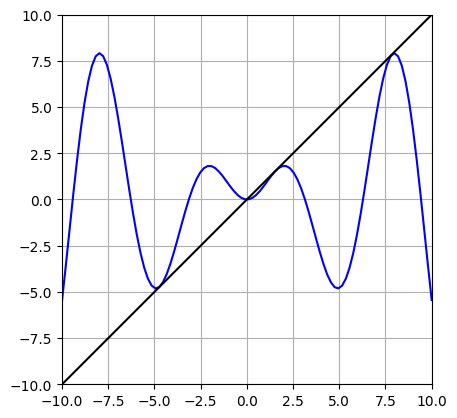

```python
F = lambda x: x * np.sin(x)
cobweb_diagram(F, x_0=(-1.5*pi,0,0.5*pi,2.5*pi))
```

If we draw horizontal lines out from these fixed points, we can see the points that are fixed after a single iteration.

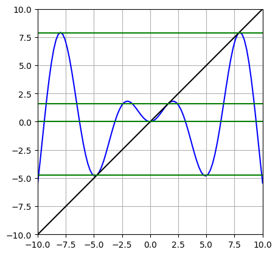

```python
xs = np.linspace(-10, 10, 100)
plt.plot(xs, F(xs), 'b')
plt.plot([-10,10], [-10,10], 'k')

# Draw horizontal lines
plt.plot([-10,10], [-1.5*pi,-1.5*pi], 'g')
plt.plot([-10,10], [0,0], 'g')
plt.plot([-10,10], [0.5*pi,0.5*pi], 'g')
plt.plot([-10,10], [2.5*pi,2.5*pi], 'g')

# Make it look pretty
plt.axis('square')
plt.axis((-10,10,-10,10))
plt.grid()
plt.show()
```

We can use the fact that $x\sin x$ is symmetric to find some of these. Let's check the mirrors of the fixed points.

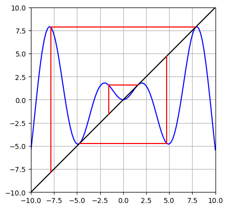

```python
cobweb_diagram(F, x_0=(-2.5*pi,-0.5*pi,1.5*pi))
```

And intersections with $y = 0$ are fairly easy to find. These occur for all $x = \pi k$ where $k \in \mathbb{Z}$.

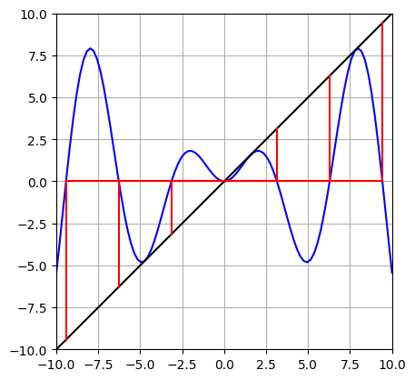

```python
cobweb_diagram(F, x_0=(-3*pi,-2*pi,-pi,pi,2*pi,3*pi))
```

But the rest of the intersecions can't be calculated mathematically (at least to my knowledge), so we'll estimate them using numerical methods. For this, we'll use the derivative $F'(x) = x\cos x + \sin x$.

```python
F_prime = lambda x: x * cos(x) + sin(x)

# Intersections with y = 0.5*pi
print('Intersections with y = 0.5*pi:')
print(calculate_intercept(F, F_prime, 0.5*pi, -9))
print(calculate_intercept(F, F_prime, 0.5*pi, -6.5))
print(calculate_intercept(F, F_prime, 0.5*pi, -2.5))
print(calculate_intercept(F, F_prime, 0.5*pi, 2.5))
print(calculate_intercept(F, F_prime, 0.5*pi, 6.5))
print(calculate_intercept(F, F_prime, 0.5*pi, 9))
print()

# Intersections with y = -1.5*pi
print('Intersections with y = -1.5*pi:')
print(calculate_intercept(F, F_prime, -1.5*pi, -10))
print(calculate_intercept(F, F_prime, -1.5*pi, -5.5))
print(calculate_intercept(F, F_prime, -1.5*pi, 5.5))
print(calculate_intercept(F, F_prime, -1.5*pi, 10))
print()

# Intersections with y = 2.5*pi
print('Intersections with y = 2.5*pi:')
print(calculate_intercept(F, F_prime, 2.5*pi, -8.5))
print(calculate_intercept(F, F_prime, 2.5*pi, 8.5))

# Store results in a dictionary
intersections = {
    '0.5pi' : [calculate_intercept(F, F_prime, 0.5*pi, -9),
               calculate_intercept(F, F_prime, 0.5*pi, -6.5),
               calculate_intercept(F, F_prime, 0.5*pi, -2.5),
               calculate_intercept(F, F_prime, 0.5*pi, 2.5),
               calculate_intercept(F, F_prime, 0.5*pi, 6.5),
               calculate_intercept(F, F_prime, 0.5*pi, 9)],

    '-1.5pi' : [calculate_intercept(F, F_prime, -1.5*pi, -10),
                calculate_intercept(F, F_prime, -1.5*pi, -5.5),
                calculate_intercept(F, F_prime, -1.5*pi, 5.5),
                calculate_intercept(F, F_prime, -1.5*pi, 10)],

    '2.5pi' : [calculate_intercept(F, F_prime, 2.5*pi, -8.5),
               calculate_intercept(F, F_prime, 2.5*pi, 8.5)]
}
```

```
Intersections with y = 0.5*pi:
-9.254213650017624
-6.526260523514655
-2.443322686566392
2.443322686566392
6.526260523514655
9.254213650017624

Intersections with y = -1.5*pi:
-9.919797568933081
-5.109025786412278
5.109025786412278
9.919797568933081

Intersections with y = 2.5*pi:
-8.102101487957542
8.102101487957542
```

Let's verify these points graphically.

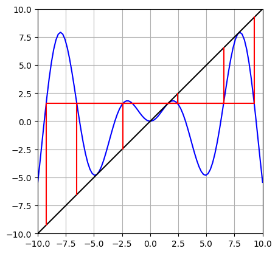

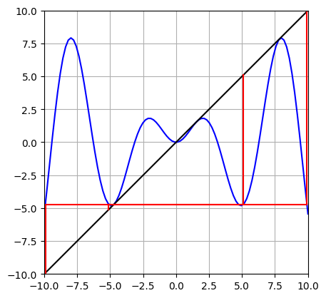

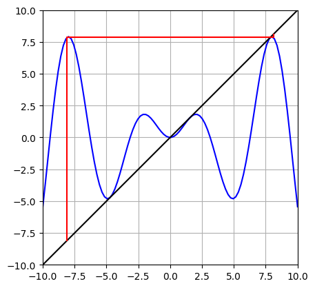

```python
cobweb_diagram(F, x_0=intersections['0.5pi'])
cobweb_diagram(F, x_0=intersections['-1.5pi'])
cobweb_diagram(F, x_0=intersections['2.5pi'])
```

Now using the points we've found so far, we can find the seed values that become fixed after two iterations.

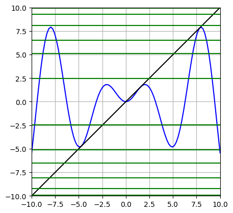

```python
xs = np.linspace(-10, 10, 100)
plt.plot(xs, F(xs), 'b')
plt.plot([-10,10], [-10,10], 'k')

# Draw horizontal lines
for intersect in intersections:
    for seed in intersections[intersect]:
        plt.plot([-10,10], [seed,seed], 'g')

# Make it look pretty
plt.axis('square')
plt.axis((-10,10,-10,10))
plt.grid()
plt.show()
```

```python
# Intersections with y = -5.11
print('Intersections with y = -5.11:')
print(calculate_intercept(F, F_prime, intersections['-1.5pi'][1], -10))
print(calculate_intercept(F, F_prime, intersections['-1.5pi'][1], 10))
print()

# Intersections with y = -pi
print('Intersections with y = -pi')
print(calculate_intercept(F, F_prime, -pi, -10))
print(calculate_intercept(F, F_prime, -pi, -6))
print(calculate_intercept(F, F_prime, -pi, 6))
print(calculate_intercept(F, F_prime, -pi, 10))
print()

# Intersections with y = -2.44
print('Intersections with y = -2.44:')
print(calculate_intercept(F, F_prime, intersections['0.5pi'][2], -10))
print(calculate_intercept(F, F_prime, intersections['0.5pi'][2], -6))
print(calculate_intercept(F, F_prime, intersections['0.5pi'][2], -4))
print(calculate_intercept(F, F_prime, intersections['0.5pi'][2], 4))
print(calculate_intercept(F, F_prime, intersections['0.5pi'][2], 6))
print(calculate_intercept(F, F_prime, intersections['0.5pi'][2], 10))
print()

# Intersections with y = -0.5pi
print('Intersections with y = -0.5pi')
print(calculate_intercept(F, F_prime, -0.5*pi, -10))
print(calculate_intercept(F, F_prime, -0.5*pi, -6))
print(calculate_intercept(F, F_prime, -0.5*pi, -4))
print(calculate_intercept(F, F_prime, -0.5*pi, 4))
print(calculate_intercept(F, F_prime, -0.5*pi, 6))
print(calculate_intercept(F, F_prime, -0.5*pi, 10))
print()

# Intersections with y = 2.44
print('Intersections with y = 2.44')
print(calculate_intercept(F, F_prime, intersections['0.5pi'][3], -9))
print(calculate_intercept(F, F_prime, intersections['0.5pi'][3], -6))
print(calculate_intercept(F, F_prime, intersections['0.5pi'][3], 6))
print(calculate_intercept(F, F_prime, intersections['0.5pi'][3], 9))
print()

# Intersections with y = pi
print('Intersections with y = pi')
print(calculate_intercept(F, F_prime, pi, -9))
print(calculate_intercept(F, F_prime, pi, -6))
print(calculate_intercept(F, F_prime, pi, 6))
print(calculate_intercept(F, F_prime, pi, 9))
print()

# Intersections with y = 5.11
print('Intersections with y = 5.11')
print(calculate_intercept(F, F_prime, intersections['-1.5pi'][2], -9))
print(calculate_intercept(F, F_prime, intersections['-1.5pi'][2], -7))
print(calculate_intercept(F, F_prime, intersections['-1.5pi'][2], 7))
print(calculate_intercept(F, F_prime, intersections['-1.5pi'][2], 9))
print()

# Intersections with y = 2pi
print('Intersections with y = 2pi')
print(calculate_intercept(F, F_prime, 2*pi, -9))
print(calculate_intercept(F, F_prime, 2*pi, -7))
print(calculate_intercept(F, F_prime, 2*pi, 7))
print(calculate_intercept(F, F_prime, 2*pi, 9))
print()

# Intersections with y = 6.53
print('Intersections with y = 6.53')
print(calculate_intercept(F, F_prime, intersections['0.5pi'][4], -8))
print(calculate_intercept(F, F_prime, intersections['0.5pi'][4], -7))
print(calculate_intercept(F, F_prime, intersections['0.5pi'][4], 7))
print(calculate_intercept(F, F_prime, intersections['0.5pi'][4], 8))

# Add results to previous dictionary
intersections['-5.11'] = [calculate_intercept(F, F_prime, intersections['-1.5pi'][1], -10),
                          calculate_intercept(F, F_prime, intersections['-1.5pi'][1], 10)]

intersections['-pi'] = [calculate_intercept(F, F_prime, -pi, -10),
                        calculate_intercept(F, F_prime, -pi, -6),
                        calculate_intercept(F, F_prime, -pi, 6),
                        calculate_intercept(F, F_prime, -pi, 10)]

intersections['-2.44'] = [calculate_intercept(F, F_prime, intersections['0.5pi'][2], -10),
                          calculate_intercept(F, F_prime, intersections['0.5pi'][2], -6),
                          calculate_intercept(F, F_prime, intersections['0.5pi'][2], -4),
                          calculate_intercept(F, F_prime, intersections['0.5pi'][2], 4),
                          calculate_intercept(F, F_prime, intersections['0.5pi'][2], 6),
                          calculate_intercept(F, F_prime, intersections['0.5pi'][2], 10)]

intersections['-0.5pi'] = [calculate_intercept(F, F_prime, -0.5*pi, -10),
                           calculate_intercept(F, F_prime, -0.5*pi, -6),
                           calculate_intercept(F, F_prime, -0.5*pi, -4),
                           calculate_intercept(F, F_prime, -0.5*pi, 4),
                           calculate_intercept(F, F_prime, -0.5*pi, 6),
                           calculate_intercept(F, F_prime, -0.5*pi, 10)]

intersections['2.44'] = [calculate_intercept(F, F_prime, intersections['0.5pi'][3], -9),
                         calculate_intercept(F, F_prime, intersections['0.5pi'][3], -6),
                         calculate_intercept(F, F_prime, intersections['0.5pi'][3], 6),
                         calculate_intercept(F, F_prime, intersections['0.5pi'][3], 9)]

intersections['pi'] = [calculate_intercept(F, F_prime, pi, -9),
                       calculate_intercept(F, F_prime, pi, -6),
                       calculate_intercept(F, F_prime, pi, 6),
                       calculate_intercept(F, F_prime, pi, 9)]

intersections['5.11'] = [calculate_intercept(F, F_prime, intersections['-1.5pi'][2], -9),
                         calculate_intercept(F, F_prime, intersections['-1.5pi'][2], -7),
                         calculate_intercept(F, F_prime, intersections['-1.5pi'][2], 7),
                         calculate_intercept(F, F_prime, intersections['-1.5pi'][2], 9)]

intersections['2pi'] = [calculate_intercept(F, F_prime, 2*pi, -9),
                        calculate_intercept(F, F_prime, 2*pi, -7),
                        calculate_intercept(F, F_prime, 2*pi, 7),
                        calculate_intercept(F, F_prime, 2*pi, 9)]

intersections['6.53'] = [calculate_intercept(F, F_prime, intersections['0.5pi'][4], -8),
                         calculate_intercept(F, F_prime, intersections['0.5pi'][4], -7),
                         calculate_intercept(F, F_prime, intersections['0.5pi'][4], 7),
                         calculate_intercept(F, F_prime, intersections['0.5pi'][4], 8)]
```

```
Intersections with y = -5.11:
-9.963208487016399
9.963208487016399

Intersections with y = -pi
-9.752749948040064
-5.699361557484731
5.699361557484731
9.752749948040064

Intersections with y = -2.44:
-9.679948783602313
-5.852511989430715
-3.832809970424864
3.832809970424864
5.852511989430715
9.679948783602313

Intersections with y = -0.5pi
-9.589326257258293
-6.019162645251092
-3.5939302541635367
3.5939302541635367
6.019162645251092
9.589326257258293

Intersections with y = 2.44
-9.154607833717213
-6.658888236701425
6.658888236701425
9.154607833717213

Intersections with y = pi
-9.07112290375477
-6.766048790452746
6.766048790452746
9.07112290375477

Intersections with y = 5.11
-8.80581913799646
-7.088122226634311
7.088122226634311
8.80581913799646

Intersections with y = 2pi
-8.606364308557731
-7.316132286079827
7.316132286079827
8.606364308557731

Intersections with y = 6.53
-15.266241940756972
-7.370628484763827
7.370628484763827
15.266241940756972
```

Now let's verify these points graphically.

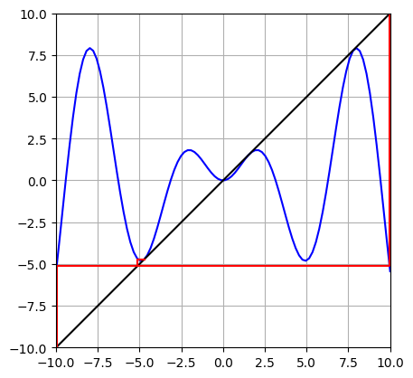

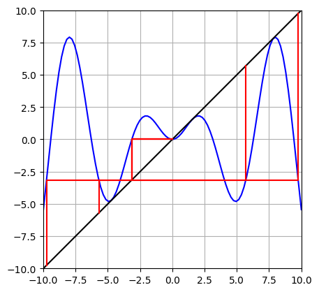

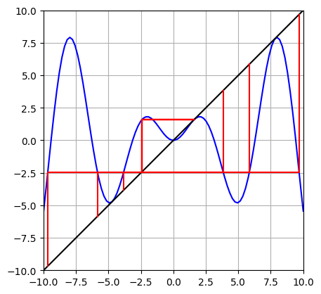

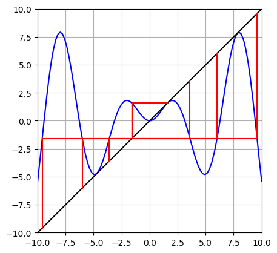

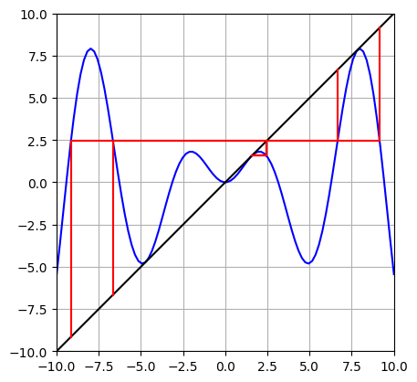

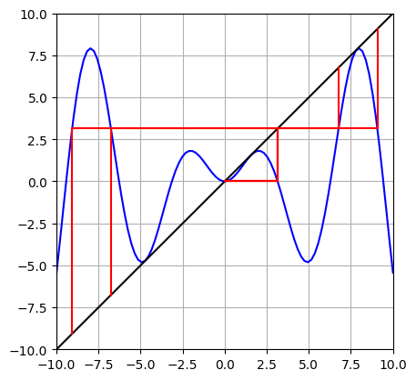

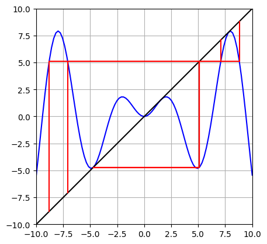

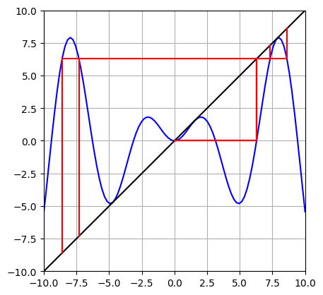

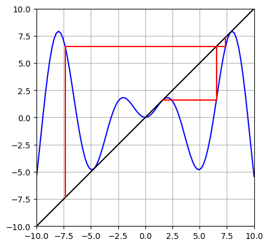

```python
cobweb_diagram(F, x_0=intersections['-5.11'])
cobweb_diagram(F, x_0=intersections['-pi'])
cobweb_diagram(F, x_0=intersections['-2.44'])
cobweb_diagram(F, x_0=intersections['-0.5pi'])
cobweb_diagram(F, x_0=intersections['2.44'])
cobweb_diagram(F, x_0=intersections['pi'])
cobweb_diagram(F, x_0=intersections['5.11'])
cobweb_diagram(F, x_0=intersections['2pi'])
cobweb_diagram(F, x_0=intersections['6.53'])
```

Now, let's put all of our current and eventual fixed points into a scatter plot and see if we can detect any patterns.

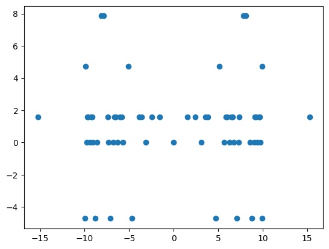

```python
xs = [-1.5*pi,0,0.5*pi,2.5*pi,-2.5*pi,-0.5*pi,1.5*pi,-3*pi,-2*pi,-pi,pi,2*pi,3*pi]
xs += intersections['0.5pi'] + intersections['-1.5pi'] + intersections['2.5pi']
xs += intersections['-5.11'] + intersections['-pi'] + intersections['-2.44']
xs += intersections['-0.5pi'] + intersections['2.44'] + intersections['pi']
xs += intersections['5.11'] + intersections['2pi'] + intersections['6.53']

ys = [-1.5*pi,0,0.5*pi,2.5*pi,2.5*pi,0.5*pi,-1.5*pi,0,0,0,0,0,0]
ys += [0.5*pi,0.5*pi,0.5*pi,0.5*pi,0.5*pi,0.5*pi,1.5*pi,1.5*pi,1.5*pi,1.5*pi,2.5*pi,2.5*pi]
ys += [-1.5*pi,-1.5*pi,0,0,0,0,0.5*pi,0.5*pi,0.5*pi,0.5*pi,0.5*pi,0.5*pi]
ys += [0.5*pi,0.5*pi,0.5*pi,0.5*pi,0.5*pi,0.5*pi,0.5*pi,0.5*pi,0.5*pi,0.5*pi,0,0,0,0]
ys += [-1.5*pi,-1.5*pi,-1.5*pi,-1.5*pi,0,0,0,0,0.5*pi,0.5*pi,0.5*pi,0.5*pi]

plt.scatter(xs, ys)
```

Unfortunately, this was as far as I was able to get with my analysis. The eventual fixed points don't seem to reveal much of a pattern, and my experimentation outside of the notebook in its submitted form reveal the difficulty of maintaining accurate estimations after a few iterations, so I may be out of luck for this assignment. In this next cell, I will combine all of the information I found into the one dictionary and print it. I apologize for the lack of completeness in my analysis.

```python
intersections['2.5pi'].append(-2.5*pi)
intersections['0.5pi'].append(-0.5*pi)
intersections['-1.5pi'].append(1.5*pi)
intersections['0'] = [-3*pi,-2*pi,-pi,pi,2*pi,3*pi]

for key in intersections:
    print(f'Intersections with y = {key}:')
    for value in intersections[key]:
        print(value)
    print()
```

[output not shown]

[output cut: 32 more lines]

```
8.606364308557731

Intersections with y = 6.53:
-15.266241940756972
-7.370628484763827
7.370628484763827
15.266241940756972

Intersections with y = 0:
-9.42477796076938
-6.283185307179586
-3.141592653589793
3.141592653589793
6.283185307179586
9.42477796076938
```

## Part II. Computer Exercise

$$F(x) = x(x^2-4)$$

## C-1:

Adapting Newton's Method code to find the basin of attraction for each fixed point of F

$\textbf{Finding fixed points:}$ $$ \begin{align*} F(x) &= x \\ x(x^2 - 4) &= x \\ x^3 - 5x &= 0 \\ x(x^2 - 5) &= 0 \\ x &= 0, \pm\sqrt{5} \end{align*} $$

$\textbf{Writing basin of attraction function:}$

```python
# Returns true if a seed value converges to fixed point within max iterations
def newton_method(f, fixed_pt, seed, max_iter, tol, max_val):
    iterations = 0

    while iterations < max_iter:
        # Calculate new guess
        seed = f(seed)
        iterations += 1

        # Check if orbit has diverged
        if abs(seed) > max_val:
            return False

        # Check if method has reached desired precision
        if abs(fixed_pt - seed) < tol:
            return True

    return False

# Returns a tuple with the minimum and maximum value of the basin of attraction of a fixed pt
def find_basin(f, fixed_pt, max_iter=25, init_step=0.1, tol=1e-9, max_val=1e9):
    # Find lower limit of basin of attraction
    step = init_step
    seed = fixed_pt - step
    infinite_limit = False

    # Move away from fp to the left, doubling step each time
    while newton_method(f, fixed_pt, seed, max_iter, tol, max_val):
        step *= 2
        seed -= step
        if seed < -max_val:
            lower_limit = -inf
            infinite_limit = True

    # Zero in on lower edge of basin
    if not infinite_limit:
        while step > tol:
            step *= 0.5
            if newton_method(f, fixed_pt, seed, max_iter, tol, max_val):
                seed -= step
            else:
                seed += step

        lower_limit = seed

    # Find upper limit of basin of attraction
    step = init_step
    seed = fixed_pt + step

    # Move away from fp to the right, doubling step each time
    while newton_method(f, fixed_pt, seed, max_iter, tol, max_val):
        step *= 2
        seed += step
        if seed > max_val:
            upper_limit = inf
            return (lower_limit, upper_limit)

    # Zero in on upper edge of basin
    while step > tol:
        step *= 0.5
        if newton_method(f, fixed_pt, seed, max_iter, tol, max_val):
            seed += step
        else:
            seed -= step

    upper_limit = seed

    # Return basin of attraction
    return (lower_limit, upper_limit)
```

$\textbf{Finding basins of attraction:}$

Basins of attraction on $F$:

```python
F = lambda x: x * (x**2 - 4)

print('-sqrt(5) basin of attraction:')
print(find_basin(F, -sqrt(5)), '\n')

print('0 basin of attraction:')
print(find_basin(F, 0), '\n')

print('sqrt(5) basin of attraction')
print(find_basin(F, sqrt(5)))
```

```
-sqrt(5) basin of attraction:
(-2.236067978244848, -2.2360679767547316)

0 basin of attraction:
(-7.450580596923829e-10, 7.450580596923829e-10)

sqrt(5) basin of attraction
(2.2360679767547316, 2.236067978244848)
```

Basins of attraction on $N$ (fixed points will be 0's on $F$, so -2, 0, and 2):

```python
N = lambda x: x - F(x) / (3*x**2 - 4)

print('-2 basin of attraction:')
print(find_basin(N, -2), '\n')

print('0 basin of attraction:')
print(find_basin(N, 0), '\n')

print('2 basin of attraction:')
print(find_basin(N, 2))
```

```
-2 basin of attraction:
(-9401.959419571604, -1.1547714568674563)

0 basin of attraction:
(-0.8944271914660935, 0.8944271914660935)

2 basin of attraction:
(1.1547714568674563, 9401.959419571604)
```

## C-2:

This structure of basins of attraction imply that certain values can cause Newton's method to fail. These values seem to coincide with the values where $F'(x)$ is near 0.

## C-3:

The set of initial values in the domain of $F$ for which Newton's method will fail is approximately $(-1.155, -0.894) \cup (0.894, 1.155)$. Let's look at a graph of $N$ to see why this is the case

```
(-5.0, 5.0, -5.0, 5.0)
```

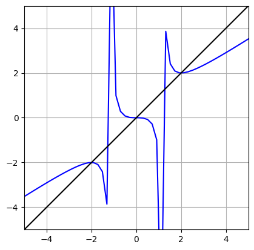

```python
xs = np.linspace(-10, 10, 100)
plt.plot(xs, N(xs), 'b')
plt.plot([-10,10], [-10,10], 'k')
plt.grid()
plt.axis('square')
plt.axis((-5,5,-5,5))
```

It looks like the regions where Newton's method failed lie near or within vertical asymptotes. This would imply that near 0 values of $F'(x)$ cause Newton's method to fail.